# 2017. 07. 10. 공부한 내용

# 왜 Word Embeddings 를 배워야하지?

잘 모르겠음  
말만 번지르르함

Mikolov et al. 의 논문

### "Distributed Representations of Words and Phrases and their Compositionality" [Link](http://papers.nips.cc/paper/5021-distributed-representations-of-words-and-phrases-and-their-compositionality.pdf)

의 word2vec 모델을 살펴본다. 이 모델은 "word embeddings" 라 불리는 단어들의 벡터 표현 학습에 사용된다.

# Noise-Contrastive 학습을 이용한 규모확장

신경 확률 언어 모델(NPLM; Neural probabilistic language models)은 일반적으로 softmax function에 대해  
h : 이전에 주어진 단어들 (history)  
w : 다음 단어 (target)  
에 대한 확률을 최대화하는 maximum likelihood의 원리를 이용하여 학습된다.

\begin{align} P(w_t | h) &= \text{softmax}(\text{score}(w_t, h)) \\ &= \frac{\exp \{ \text{score}(w_t, h) \} } {\sum_\text{Word w' in Vocab} \exp \{ \text{score}(w', h) \} } \end{align}

score(w, h)은 컨텍스트와 함께 하는 단어의 호환성을 계산한다.(내적)  
학습하는 set에서 이것의 log-likelihood 를 최대하 함으로써 모델을 학습니다.

\begin{align} J_\text{ML} &= \log P(w_t | h) \\ &= \text{score}(w_t, h) - \log \left( \sum_\text{Word w' in Vocab} \exp \{ \text{score}(w', h) \} \right). \end{align}

매 학습 스템, 현대 컨텍스트 h 에서 다은 모든 V words w' 에 대한 범위흫 이용한 각 확률을 계산하고 정규화하는 것이 필요하기 때문에 그 비용이 매우 비싸다.

반면, word2vec의 feature 학습에 대하여 완전 확률 모델(a full probabilistic model)을 필효로 하지 않는다.  
대신 CBOW와 skip-gram 모델은 같은 컨텍스트 내에서 실제 타겟 단어들 w을 가상단어들 w''로부터 구별해 내기 위한 이진 분류 목적함수 (logistic)를 이용하여 학습되어 진다.

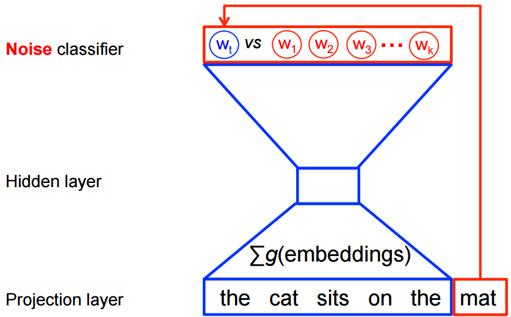

```python
from IPython.display import Image
Image('images/nce-nplm.png')
```

수학적으로, 목적함수는 이를 최대화 한다.

\begin{align} J_\text{NEG} = \log Q_\theta(D=1 |w_t, h) + k \mathop{\mathbb{E}}_{\tilde w \sim P_\text{noise}} \left[ \log Q_\theta(D = 0 |\tilde w, h) \right] \end{align}

$Q_\theta(D=1 | w, h)$은 학습된 embedding vectors $\theta$에 대하 계산된 datasetD 내 컨텍스트h 에서 보여지는 단어 w의 모델에 대해서 로지스틱 회귀 학률인 조건이다.

이 목적함수는 모델이 실제 단어들에 높은 확률을 할당하고 노이즈 단어들에 낮은 확률을 할당할 때 최대화된다. 기술적으로 이를 nagative Sampling이라 한다.  
손실함수의 계산을 어휘(V)내 모든 단어가 아닌 우리가 선택한 noise words(k)의 갯수만으로 변경하여 계산한다는 점 때문에 계산적으로 매력적이다.

# [Graph 구성하기 Github_code](https://github.com/tensorflow/tensorflow/blob/master/tensorflow/examples/tutorials/word2vec/word2vec_basic.py)

```python
"""Basic word2vec example."""

from __future__ import absolute_import
from __future__ import division
from __future__ import print_function

import collections
import math
import os
import random
import zipfile

import numpy as np
from six.moves import urllib
from six.moves import xrange  # pylint: disable=redefined-builtin
import tensorflow as tf
```

```python
# Step 1: Download the data.
url = 'http://mattmahoney.net/dc/'

def maybe_download(filename, expected_bytes):
  """Download a file if not present, and make sure it's the right size."""
  if not os.path.exists(filename):
    filename, _ = urllib.request.urlretrieve(url + filename, filename)
  statinfo = os.stat(filename)
  if statinfo.st_size == expected_bytes:
    print('Found and verified', filename)
  else:
    print(statinfo.st_size)
    raise Exception(
        'Failed to verify ' + filename + '. Can you get to it with a browser?')
  return filename

filename = maybe_download('text8.zip', 31344016)

# Read the data into a list of strings.
def read_data(filename):
  """Extract the first file enclosed in a zip file as a list of words."""
  with zipfile.ZipFile(filename) as f:
    data = tf.compat.as_str(f.read(f.namelist()[0])).split()
  return data
```

```
Found and verified text8.zip
```

```python
vocabulary = read_data(filename)
print('Data size', len(vocabulary))

# Step 2: Build the dictionary and replace rare words with UNK token.
vocabulary_size = 50000


def build_dataset(words, n_words):
  """Process raw inputs into a dataset."""
  count = [['UNK', -1]]
  count.extend(collections.Counter(words).most_common(n_words - 1))
  dictionary = dict()
  for word, _ in count:
    dictionary[word] = len(dictionary)
  data = list()
  unk_count = 0
  for word in words:
    if word in dictionary:
      index = dictionary[word]
    else:
      index = 0  # dictionary['UNK']
      unk_count += 1
    data.append(index)
  count[0][1] = unk_count
  reversed_dictionary = dict(zip(dictionary.values(), dictionary.keys()))
  return data, count, dictionary, reversed_dictionary

data, count, dictionary, reverse_dictionary = build_dataset(vocabulary,
                                                            vocabulary_size)
del vocabulary  # Hint to reduce memory.
print('Most common words (+UNK)', count[:5])
print('Sample data', data[:10], [reverse_dictionary[i] for i in data[:10]])
```

```
Data size 17005207
Most common words (+UNK) [['UNK', 418391], ('the', 1061396), ('of', 593677), ('and', 416629), ('one', 411764)]
Sample data [5234, 3081, 12, 6, 195, 2, 3135, 46, 59, 156] ['anarchism', 'originated', 'as', 'a', 'term', 'of', 'abuse', 'first', 'used', 'against']
```

```python
data_index = 0

# Step 3: Function to generate a training batch for the skip-gram model.
def generate_batch(batch_size, num_skips, skip_window):
  global data_index
  assert batch_size % num_skips == 0
  assert num_skips <= 2 * skip_window
  batch = np.ndarray(shape=(batch_size), dtype=np.int32)
  labels = np.ndarray(shape=(batch_size, 1), dtype=np.int32)
  span = 2 * skip_window + 1  # [ skip_window target skip_window ]
  buffer = collections.deque(maxlen=span)
  if data_index + span > len(data):
    data_index = 0
  buffer.extend(data[data_index:data_index + span])
  data_index += span
  for i in range(batch_size // num_skips):
    target = skip_window  # target label at the center of the buffer
    targets_to_avoid = [skip_window]
    for j in range(num_skips):
      while target in targets_to_avoid:
        target = random.randint(0, span - 1)
      targets_to_avoid.append(target)
      batch[i * num_skips + j] = buffer[skip_window]
      labels[i * num_skips + j, 0] = buffer[target]
    if data_index == len(data):
      buffer[:] = data[:span]
      data_index = span
    else:
      buffer.append(data[data_index])
      data_index += 1
  # Backtrack a little bit to avoid skipping words in the end of a batch
  data_index = (data_index + len(data) - span) % len(data)
  return batch, labels
```

```python
batch, labels = generate_batch(batch_size=8, num_skips=2, skip_window=1)
for i in range(8):
  print(batch[i], reverse_dictionary[batch[i]],
        '->', labels[i, 0], reverse_dictionary[labels[i, 0]])
```

```
3081 originated -> 5234 anarchism
3081 originated -> 12 as
12 as -> 3081 originated
12 as -> 6 a
6 a -> 12 as
6 a -> 195 term
195 term -> 2 of
195 term -> 6 a
```

```python
# Step 4: Build and train a skip-gram model.

batch_size = 128
embedding_size = 128  # Dimension of the embedding vector.
skip_window = 1       # How many words to consider left and right.
num_skips = 2         # How many times to reuse an input to generate a label.

# We pick a random validation set to sample nearest neighbors. Here we limit the
# validation samples to the words that have a low numeric ID, which by
# construction are also the most frequent.
valid_size = 16     # Random set of words to evaluate similarity on.
valid_window = 100  # Only pick dev samples in the head of the distribution.
valid_examples = np.random.choice(valid_window, valid_size, replace=False)
num_sampled = 64    # Number of negative examples to sample.
```

```python
graph = tf.Graph()

with graph.as_default():

  # Input data.
  train_inputs = tf.placeholder(tf.int32, shape=[batch_size])
  train_labels = tf.placeholder(tf.int32, shape=[batch_size, 1])
  valid_dataset = tf.constant(valid_examples, dtype=tf.int32)

  # Ops and variables pinned to the CPU because of missing GPU implementation
  with tf.device('/cpu:0'):
    # Look up embeddings for inputs.
    embeddings = tf.Variable(
        tf.random_uniform([vocabulary_size, embedding_size], -1.0, 1.0))
    embed = tf.nn.embedding_lookup(embeddings, train_inputs)

    # Construct the variables for the NCE loss
    nce_weights = tf.Variable(
        tf.truncated_normal([vocabulary_size, embedding_size],
                            stddev=1.0 / math.sqrt(embedding_size)))
    nce_biases = tf.Variable(tf.zeros([vocabulary_size]))

  # Compute the average NCE loss for the batch.
  # tf.nce_loss automatically draws a new sample of the negative labels each
  # time we evaluate the loss.
  loss = tf.reduce_mean(
      tf.nn.nce_loss(weights=nce_weights,
                     biases=nce_biases,
                     labels=train_labels,
                     inputs=embed,
                     num_sampled=num_sampled,
                     num_classes=vocabulary_size))

  # Construct the SGD optimizer using a learning rate of 1.0.
  optimizer = tf.train.GradientDescentOptimizer(1.0).minimize(loss)

  # Compute the cosine similarity between minibatch examples and all embeddings.
  norm = tf.sqrt(tf.reduce_sum(tf.square(embeddings), 1, keep_dims=True))
  normalized_embeddings = embeddings / norm
  valid_embeddings = tf.nn.embedding_lookup(
      normalized_embeddings, valid_dataset)
  similarity = tf.matmul(
      valid_embeddings, normalized_embeddings, transpose_b=True)

  # Add variable initializer.
  init = tf.global_variables_initializer()
```

```python
# Step 5: Begin training.
num_steps = 100001

with tf.Session(graph=graph) as session:
  # We must initialize all variables before we use them.
  init.run()
  print('Initialized')

  average_loss = 0
  for step in xrange(num_steps):
    batch_inputs, batch_labels = generate_batch(
        batch_size, num_skips, skip_window)
    feed_dict = {train_inputs: batch_inputs, train_labels: batch_labels}

    # We perform one update step by evaluating the optimizer op (including it
    # in the list of returned values for session.run()
    _, loss_val = session.run([optimizer, loss], feed_dict=feed_dict)
    average_loss += loss_val

    if step % 2000 == 0:
      if step > 0:
        average_loss /= 2000
      # The average loss is an estimate of the loss over the last 2000 batches.
      print('Average loss at step ', step, ': ', average_loss)
      average_loss = 0

    # Note that this is expensive (~20% slowdown if computed every 500 steps)
    if step % 10000 == 0:
      sim = similarity.eval()
      for i in xrange(valid_size):
        valid_word = reverse_dictionary[valid_examples[i]]
        top_k = 8  # number of nearest neighbors
        nearest = (-sim[i, :]).argsort()[1:top_k + 1]
        log_str = 'Nearest to %s:' % valid_word
        for k in xrange(top_k):
          close_word = reverse_dictionary[nearest[k]]
          log_str = '%s %s,' % (log_str, close_word)
        print(log_str)
  final_embeddings = normalized_embeddings.eval()
```

```
Initialized
Average loss at step  0 :  280.841827393
Nearest to for: heritable, indeterminate, chant, deconstruction, mam, revoked, wrecked, slipped,
Nearest to six: rusty, tyrants, ashton, cebit, webster, secession, preferring, pretext,
Nearest to no: mutinies, easterly, sartre, lurker, perot, julmust, evening, sennacherib,
Nearest to nine: rhinoceros, dundas, hardwired, tyre, inr, wallpaper, nominative, covert,
Nearest to will: erg, unfinished, ardent, clades, asked, zorro, usefulness, invested,
Nearest to many: societal, brokerage, weakens, duckburg, firsts, ern, disappearance, helen,
Nearest to are: gideon, coordinators, tarawa, sicilian, napo, pigweed, mainstay, kirk,
Nearest to in: modeling, poised, bioethics, apogee, zhou, stirred, fta, fleshy,
Nearest to called: hmg, secant, phonemic, offered, sitcoms, australian, sizable, thermodynamic,
Nearest to i: lobbied, betraying, abstention, laga, perugia, exodus, roles, crusader,
Nearest to by: scavenge, kshatriya, turn, slaughtered, pnc, meine, approximately, duration,
Nearest to war: speckled, astrodome, germs, depriving, ldots, nothing, electroacoustic, quotas,
Nearest to eight: indulged, rudolph, lez, sustenance, montag, romanized, vega, ballad,
Nearest to their: user, fulton, hospitality, noticable, mendicant, luca, practicing, prolog,
Nearest to who: nanotube, dunlop, magazines, kamakura, gl, lps, carboxylate, joysticks,
Nearest to when: amanullah, genesee, kofi, renewable, waterhouse, presse, valiente, arcades,
Average loss at step  2000 :  113.770907725
Average loss at step  4000 :  52.3223398139
Average loss at step  6000 :  33.5140214703
Average loss at step  8000 :  23.3920634458
Average loss at step  10000 :  17.9430364372
Nearest to for: in, and, of, slipped, chant, gb, sentence, agave,
Nearest to six: nine, zero, four, eight, archie, basins, one, deke,
Nearest to no: perot, shown, archie, evening, series, mathbf, reference, held,
Nearest to nine: zero, archie, one, eight, six, aberdeen, gb, austin,
Nearest to will: unfinished, asked, bckgr, dead, mysore, old, owed, refusing,
Nearest to many: sky, the, beings, war, peculiar, beard, done, societal,
Nearest to are: is, and, bang, stanley, were, mainstay, lnot, clare,
Nearest to in: and, of, from, nine, on, for, basins, with,
Nearest to called: australian, offered, opening, als, speer, coke, childhood, pursuits,
Nearest to i: lobbied, betraying, roles, exodus, built, protect, cyborg, gb,
Nearest to by: and, in, from, turn, processors, domestic, approximately, UNK,
Nearest to war: nothing, successful, many, meaningless, survey, altenberg, transmitting, depriving,
Nearest to eight: zero, nine, rudolph, six, austin, four, aberdeen, archie,
Nearest to their: the, user, poplar, him, literary, measured, neutrino, no,
Nearest to who: also, just, magazines, braun, s, he, commercially, python,
Nearest to when: aberdeen, agave, zero, milne, absurd, usual, good, sense,
Average loss at step  12000 :  13.9585361403
```

[output cut: 173 more lines]

```
Nearest to six: seven, eight, five, four, nine, three, zero, two,
Nearest to no: shown, perot, still, judaean, it, a, only, feather,
Nearest to nine: eight, seven, six, five, zero, four, ursus, agouti,
Nearest to will: would, can, may, could, must, should, might, cannot,
Nearest to many: some, several, these, various, all, other, such, most,
Nearest to are: were, have, is, these, although, samba, while, including,
Nearest to in: during, from, gollancz, at, under, on, within, dasyprocta,
Nearest to called: endo, speer, awarded, prohibit, operatorname, thaler, meal, als,
Nearest to i: lobbied, we, clo, ii, betraying, UNK, t, albury,
Nearest to by: through, kapoor, as, was, with, be, mico, ursus,
Nearest to war: speckled, depriving, during, tramiel, nothing, myers, shang, burnham,
Nearest to eight: seven, six, nine, five, four, zero, three, dasyprocta,
Nearest to their: its, his, her, the, some, these, him, many,
Nearest to who: he, which, they, also, dianetics, singles, never, and,
Nearest to when: after, if, through, during, where, chamada, while, although,
```

```python
# Step 6: Visualize the embeddings.


def plot_with_labels(low_dim_embs, labels, filename='tsne.png'):
  assert low_dim_embs.shape[0] >= len(labels), 'More labels than embeddings'
  plt.figure(figsize=(18, 18))  # in inches
  for i, label in enumerate(labels):
    x, y = low_dim_embs[i, :]
    plt.scatter(x, y)
    plt.annotate(label,
                 xy=(x, y),
                 xytext=(5, 2),
                 textcoords='offset points',
                 ha='right',
                 va='bottom')

  plt.savefig(filename)

try:
  # pylint: disable=g-import-not-at-top
  from sklearn.manifold import TSNE
  import matplotlib.pyplot as plt

  tsne = TSNE(perplexity=30, n_components=2, init='pca', n_iter=5000)
  plot_only = 500
  low_dim_embs = tsne.fit_transform(final_embeddings[:plot_only, :])
  labels = [reverse_dictionary[i] for i in xrange(plot_only)]
  plot_with_labels(low_dim_embs, labels)

except ImportError:
  print('Please install sklearn, matplotlib, and scipy to show embeddings.')
```

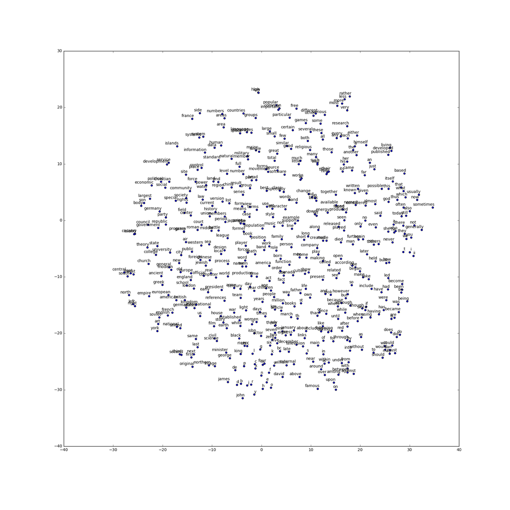

```python
from IPython.display import Image
Image('tsne.png')
```